# Beyond MLR Lab 5: Nightly prices in Chicago neighborhoods

Model answers · Week 3

# Chicago Airbnb listings

The Chicago Airbnb data contain 1,561 listings in 43 neighborhoods. Trinh and Ameri compiled the data for a St. Olaf College project, and the dataset accompanies *Beyond Multiple Linear Regression* by Roback and Legler. Each row describes one listing. We study the 826 listings for entire homes or apartments in 36 neighborhoods. The outcome is the **listed price in US dollars per night**.

Two homes in the same neighborhood can have different nightly prices. Average prices can also differ between neighborhoods. We examine how much prices vary at each level and how much of that variation remains after accounting for the number of guests a home accommodates and the walkability of its neighborhood.

# Setup and data

Create a `week3` folder with a `data` subfolder. Download the Chicago Airbnb data and save the file as `week3/data/airbnb.csv`. Save your script as `lab5.R` in `week3` and set that folder as your working directory. Install the packages with `pak` if needed, as described in Lab 1.

```r
library(pak)
pkg_install(c("dplyr", "ggplot2", "lme4", "lmerTest"))
```

```r
library(dplyr)
library(ggplot2)
library(lme4)
library(lmerTest)

airbnb <- read.csv("data/airbnb.csv")
airbnb <- filter(airbnb, room_type == "Entire home/apt")
airbnb$neighborhood <- factor(airbnb$neighborhood)
```

# Count the listings in each neighborhood

The bars show how many entire homes each neighborhood contributes, with the six largest counts highlighted.

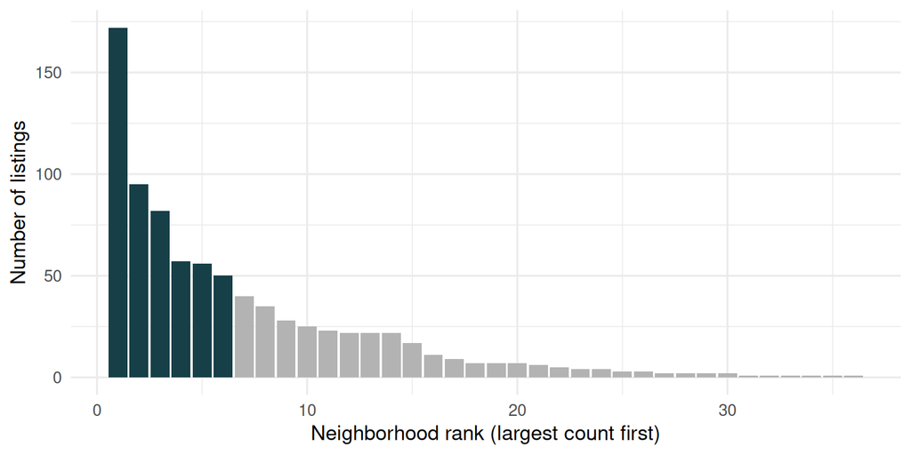

```r
neighborhood_counts <- count(airbnb, neighborhood, sort = TRUE) |>
  mutate(rank = row_number())

count_plot <- ggplot(neighborhood_counts, aes(rank, n)) +
  geom_col(aes(fill = rank <= 6), show.legend = FALSE) +
  scale_fill_manual(values = c("TRUE" = "#173F48", "FALSE" = "grey70")) +
  labs(x = "Neighborhood rank (largest count first)",
       y = "Number of listings") +
  theme_minimal(base_size = 13)
count_plot
```

```r
top_six <- slice_head(neighborhood_counts, n = 6)
top_six
```

```
   neighborhood   n rank
1  Logan Square 172    1
2     West Town  95    2
3      The Loop  82    3
4 Humboldt Park  57    4
5   Rogers Park  56    5
6  Lincoln Park  50    6
```

```r
summary(neighborhood_counts$n)
```

```
   Min. 1st Qu.  Median    Mean 3rd Qu.    Max.
   1.00    2.00    7.00   22.94   25.75  172.00
```

**ImportantQuestion 1**

How evenly are the listings distributed across neighborhoods? What does this suggest about how precisely we can estimate each neighborhood’s mean price?

**TipModel answer 1**

Logan Square contributes 172 listings, while the median neighborhood contributes only 7. With comparable variation among listings, the larger samples give more precise estimates of neighborhood mean prices.

# Compare nightly prices within and between neighborhoods

Plot the nightly prices for the six neighborhoods with the most listings. Each dot represents one listing, and each diamond marks a neighborhood mean. The dashed horizontal line marks the grand mean nightly price across all 826 entire-home listings.

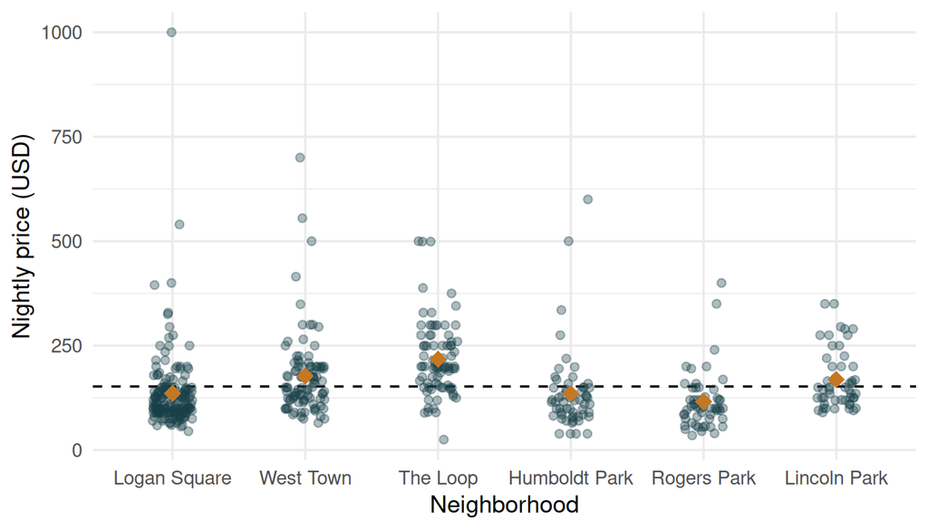

```r
example_listings <- filter(airbnb, neighborhood %in% top_six$neighborhood)

price_plot <- ggplot(example_listings, aes(neighborhood, price)) +
  geom_hline(yintercept = mean(airbnb$price), linetype = "dashed") +
  geom_point(position = position_jitter(width = 0.15, height = 0,
                                       seed = 5),
             alpha = 0.35, color = "#173F48") +
  stat_summary(fun = mean, geom = "point", shape = 18,
               size = 4, color = "#C57722") +
  scale_x_discrete(limits = as.character(top_six$neighborhood)) +
  labs(x = "Neighborhood", y = "Nightly price (USD)") +
  theme_minimal(base_size = 13)
price_plot
```

**ImportantQuestion 2**

How do the differences between neighborhood mean prices compare with the spread of listing prices within neighborhoods? What does the plot suggest about allowing each neighborhood to have its own intercept?

**TipModel answer 2**

The six means range from about $115 per night in Rogers Park to $218 in The Loop. Within each neighborhood there is considerable spread, and the price distributions overlap. Allowing a separate intercept for each neighborhood captures the differences in mean price while allowing individual listings to vary around their neighborhood mean.

**NoteNeighborhood as a fixed or random effect**

**How much do mean nightly prices differ between West Town and Rogers Park?** Treating neighborhood as a fixed effect lets us estimate this specific comparison.

**How much do mean nightly prices for entire-home Airbnb listings vary across urban neighborhoods?** This is the broader question we study in this lab. We use observations from 36 Chicago neighborhoods and model their mean prices as draws from a common distribution. The **between-neighborhood variance** describes the spread of that distribution.

# Choose a scale for nightly price

## Fit a random-intercept model for nightly price

Let $Y_{ij}$ be the nightly price in dollars for listing $i$ in neighborhood $j$. We fit the null model

$$Y_{ij}=\beta_0+c_j+\varepsilon_{ij}.$$

Neighborhood $j$ has mean nightly price $\beta_0+c_j$. The between-neighborhood variance $\sigma_c^2$ describes variation in these means. The within-neighborhood variance $\sigma^2$ describes variation among listing prices around their neighborhood mean.

```r
model_dollars <- lmer(price ~ 1 + (1 | neighborhood), data = airbnb)
```

## Examine the residuals on the dollar scale

The null model assumes the same within-neighborhood variance $\sigma^2$ in every neighborhood. We can examine that assumption by plotting the **conditional residuals** against the fitted neighborhood means. A listing’s conditional residual is its observed price minus its fitted neighborhood mean, $Y_{ij}-(\widehat\beta_0+\widehat c_j)$. Listings from the same neighborhood share a fitted value and appear in a vertical strip.

```r
plot(fitted(model_dollars), resid(model_dollars),
     xlab = "Fitted price (USD)", ylab = "Residual (USD)",
     pch = 16, col = "#173F484D")
abline(h = 0, lty = 2)
```

**ImportantQuestion 3**

How does the spread of the residuals change as the fitted nightly price increases? Does a common within-neighborhood variance seem reasonable on the dollar scale?

**TipModel answer 3**

The residuals generally have a wider spread in neighborhoods with higher fitted prices. Some observed prices are hundreds of dollars above their fitted neighborhood means. This widening spread calls the assumption of a common residual variance into question.

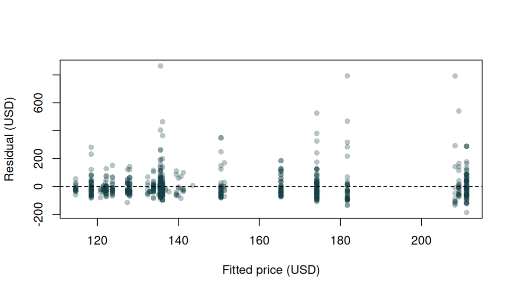

## Fit the null model to log nightly price

A log transformation expresses price differences in relative terms. For example, doubling the nightly price gives the same increase in log price whether the price rises from $50 to $100 or from $150 to $300. Fit the null model again using $L_{ij}=\log(Y_{ij})$.

$$L_{ij}=\beta_0+c_j+\varepsilon_{ij}.$$

Plot the conditional residuals against the fitted neighborhood means, both on the log scale.

```r
airbnb$log_price <- log(airbnb$price)
model_null <- lmer(log_price ~ 1 + (1 | neighborhood), data = airbnb)
```

```r
plot(fitted(model_null), resid(model_null),
     xlab = "Fitted log price", ylab = "Residual (log price)",
     pch = 16, col = "#173F484D")
abline(h = 0, lty = 2)
```

**ImportantQuestion 4**

Compare the two residual plots. On which scale does the assumption of a common within-neighborhood variance look more reasonable? What do you see that supports your choice?

**TipModel answer 4**

On the log scale, as fitted log price increases, the points show a more even vertical spread around zero. A few listings still have large residuals, but the widening pattern is much less pronounced. A common within-neighborhood variance looks more reasonable on the log scale.

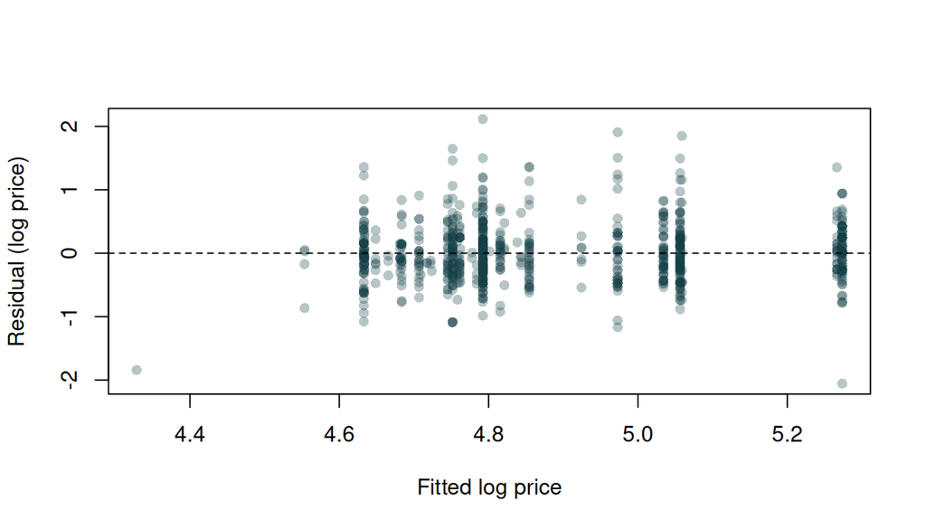

```r
print(VarCorr(model_null), comp = "Variance")
```

```
 Groups       Name        Variance
 neighborhood (Intercept) 0.052594
 Residual                 0.208006
```

**ImportantQuestion 5**

Use the estimated variance components from the log-price null model to calculate the intraclass correlation coefficient (ICC).

**TipModel answer 5**

The ICC is $\sigma_c^2/(\sigma_c^2 + \sigma^2)$. Using the unrounded variance estimates gives **20.2%** of the variation in log nightly price between neighborhoods.

# Identify listing and neighborhood covariates

**Individual-level covariates** describe a listing. For example, homes in the same neighborhood can accommodate different numbers of guests. **Context-level covariates** describe a neighborhood. All listings in a given neighborhood share its walkability score.

| Level | Covariates in the dataset |
| --- | --- |
| Individual (listing) | Guest capacity (`accommodates`), number of bedrooms (`bedrooms`), minimum stay in nights (`minstay`), number of reviews (`reviews`), and average guest rating (`overall_satisfaction`). |
| Context (neighborhood) | Walkability (`WalkScore`), access to public transit (`TransitScore`), and bikeability (`BikeScore`). |

WalkScore ranges from 0 to 100. A higher score indicates that everyday destinations such as shops and restaurants are easier to reach on foot.

## Check for missing values

Count the listings with a missing value for each covariate.

```r
covariates <- c("accommodates", "bedrooms", "minstay",
                "reviews", "overall_satisfaction",
                "WalkScore", "TransitScore", "BikeScore")
colSums(is.na(airbnb[covariates]))
```

```
        accommodates             bedrooms              minstay
                   0                    0                  104
             reviews overall_satisfaction            WalkScore
                   0                    0                    0
        TransitScore            BikeScore
                   0                    0
```

Guest capacity and WalkScore are recorded for all 826 listings. Only minimum stay has missing values (104 listings).

**NoteOptional reading: Missing minimum stays**

An analysis of minimum stay would first require checking how the data record listings with no minimum stay and those whose minimum stay is unknown.

**Complete-case analysis.** To assess the contribution of minimum stay, fit the models with and without it to the same 722 listings with a recorded value. The estimates can be biased if listings with a recorded minimum stay differ systematically from those with a missing value in ways relevant to price.

**Multiple imputation.** Use the observed data to generate several plausible values for each missing minimum stay, accounting for the grouping of listings within neighborhoods. Fit the model to each completed dataset and pool the estimates, accounting for uncertainty both within and between the completed datasets.

# Add guest capacity and neighborhood walkability

Add guest capacity to the log-price model first, then add WalkScore. Comparing the variance estimates at each step shows how much variation remains within and between neighborhoods.

## Center guest capacity

With capacity measured as the number of guests, the intercept refers to a home that accommodates zero guests. Use four guests as the reference capacity. It is both the median and the most common capacity in the sample.

**Centering at four guests** means subtracting four from each home’s capacity. We call the result $C_{ij}$.

| Guest capacity | Centered capacity, $C_{ij}$ |
| --- | --- |
| 3 | −1 |
| 4 | 0 |
| 5 | 1 |

The model with guest capacity is

$$L_{ij}=\beta_0+\beta_1 C_{ij}+c_j+\varepsilon_{ij}.$$

A four-guest home in neighborhood $j$ has expected log price $\beta_0+c_j$. The slope $\beta_1$ gives the expected difference in log price for one additional guest place within the same neighborhood. Centering changes the reference capacity and preserves the slope and fitted values.

```r
airbnb$capacity_c <- airbnb$accommodates - 4
model_listing <- lmer(log_price ~ capacity_c + (1 | neighborhood),
                      data = airbnb)
summary(model_listing)
```

```
Linear mixed model fit by REML. t-tests use Satterthwaite's method [
lmerModLmerTest]
Formula: log_price ~ capacity_c + (1 | neighborhood)
   Data: airbnb

REML criterion at convergence: 852.7

Scaled residuals:
    Min      1Q  Median      3Q     Max
-4.4685 -0.5529 -0.0675  0.5245  3.5126

Random effects:
 Groups       Name        Variance Std.Dev.
 neighborhood (Intercept) 0.06148  0.2479
 Residual                 0.15085  0.3884
Number of obs: 826, groups:  neighborhood, 36

Fixed effects:
             Estimate Std. Error        df t value Pr(>|t|)
(Intercept) 4.705e+00  4.971e-02 2.182e+01   94.66   <2e-16 ***
capacity_c  9.876e-02  5.697e-03 7.985e+02   17.34   <2e-16 ***
---
Signif. codes:  0 '***' 0.001 '**' 0.01 '*' 0.05 '.' 0.1 ' ' 1

Correlation of Fixed Effects:
           (Intr)
capacity_c -0.086
```

**ImportantQuestion 6**

What is the expected log nightly price for a four-guest home in a neighborhood with a random intercept of zero? How much higher or lower is the expected log price for a five-guest home in that same neighborhood?

**TipModel answer 6**

The estimated intercept, **4.705**, is the expected log nightly price for a four-guest home in a neighborhood with $c_j=0$. Moving from four to five guests increases centered capacity from 0 to 1, so the fitted difference in log price is the capacity slope, **0.0988**.

**NoteOptional reading: From log price to dollars**

Under the model, log nightly prices are Normally distributed for homes with the same guest capacity in the same neighborhood. On the log scale, the mean and median coincide. Exponentiating the fitted mean log price therefore gives the fitted **median nightly price in dollars**.

For example, a fitted log price of 4.6 corresponds to a median of about $99 per night (`exp(4.6)`). A fitted log price of 4.7 corresponds to about $110. The difference of 0.1 on the log scale translates to a price ratio of `exp(0.1)`, or about a 10.5% higher median nightly price.

## Center and rescale WalkScore

Add neighborhood walkability to the model with guest capacity. Define $W_j=(\mathrm{WalkScore}_j-80)/10$.

- **Subtracting 80 centers the score.** A neighborhood with a WalkScore of 80 has a centered score of zero.
- **Dividing by 10 changes the unit.** WalkScores of 80 and 90 give $W_j=0$ and $W_j=1$, respectively. One unit of $W_j$ represents ten WalkScore points.

The model with walkability is

$$L_{ij}=\beta_0+\beta_1 C_{ij}
+\beta_2 W_j+c_j+\varepsilon_{ij}.$$

The fixed intercept $\beta_0$ is the expected log price for a four-guest home at WalkScore 80 in a neighborhood with $c_j=0$. The random intercept $c_j$ is now the amount by which expected log prices in neighborhood $j$ lie above or below the values predicted from guest capacity and WalkScore alone. The coefficient $\beta_2$ gives the expected difference in log price for a ten-point increase in neighborhood WalkScore at the same guest capacity, averaged over the random neighborhood effects.

```r
airbnb$walk10 <- (airbnb$WalkScore - 80) / 10
model_walk <- update(model_listing, . ~ . + walk10)
summary(model_walk)
```

```
Linear mixed model fit by REML. t-tests use Satterthwaite's method [
lmerModLmerTest]
Formula: log_price ~ capacity_c + (1 | neighborhood) + walk10
   Data: airbnb

REML criterion at convergence: 846.1

Scaled residuals:
    Min      1Q  Median      3Q     Max
-4.7564 -0.5605 -0.0619  0.5314  3.4997

Random effects:
 Groups       Name        Variance Std.Dev.
 neighborhood (Intercept) 0.03359  0.1833
 Residual                 0.15150  0.3892
Number of obs: 826, groups:  neighborhood, 36

Fixed effects:
             Estimate Std. Error        df t value Pr(>|t|)
(Intercept) 4.703e+00  4.007e-02 2.448e+01 117.355  < 2e-16 ***
capacity_c  9.825e-02  5.696e-03 8.082e+02  17.251  < 2e-16 ***
walk10      1.526e-01  4.110e-02 3.465e+01   3.712 0.000718 ***
---
Signif. codes:  0 '***' 0.001 '**' 0.01 '*' 0.05 '.' 0.1 ' ' 1

Correlation of Fixed Effects:
           (Intr) cpcty_
capacity_c -0.106
walk10     -0.142 -0.017
```

In `update()`, `. ~ . + walk10` adds $\beta_2 W_j$ while keeping guest capacity and the random neighborhood intercept.

**ImportantQuestion 7**

For four-guest homes, what difference in mean log nightly price does the model predict between neighborhoods with WalkScores of 90 and 80 (90 minus 80)?

**TipModel answer 7**

Moving from WalkScore 80 to 90 increases `walk10` from 0 to 1. Both homes have the same capacity, so the difference predicted by the fixed effects is the `walk10` coefficient, **0.1526** on the log scale.

## Compare the variance components

For each log-price model, record the estimated within-neighborhood and between-neighborhood variances.

| Model for log price | Within-neighborhood variance | Between-neighborhood variance |
| --- | --- | --- |
| Null |  |  |
| Add guest capacity |  |  |
| Then add WalkScore |  |  |

**ImportantQuestion 8**

How do the two variance components change when you add guest capacity? What changes when you then add WalkScore?

**TipModel answer 8**

Both variance components are in squared log-price units.

| Model for log price | Within-neighborhood variance | Between-neighborhood variance |
| --- | --- | --- |
| Null | 0.208 | 0.053 |
| Add guest capacity | 0.151 | 0.061 |
| Then add WalkScore | 0.152 | 0.034 |

Adding guest capacity reduces the within-neighborhood variance from 0.208 to 0.151. Listings of the same capacity are more similar in log price. The estimated between-neighborhood variance rises from 0.053 to 0.061 when neighborhoods are compared at a common capacity.

Adding WalkScore reduces the between-neighborhood variance from 0.061 to 0.034, or about 45%. WalkScore is shared by all listings in a neighborhood, so it shifts the fitted mean for the whole neighborhood. The within-neighborhood variance stays close to 0.151.